# Regression Models

Andrew Imredy

12/10/2021

## Part III: Regression Models

**Setup:**

```r
library(tidyverse)
df <- read.csv('cs_1675_fall2021_finalproject.csv')
df <- df %>%
  mutate(x5 = 1 - (x1 + x2 + x3 + x4),
         w = x2 / (x3 + x4),
         z = (x1 + x2) / (x5 + x4),
         t = v1 * v2)
df <- df %>%
  mutate(y = boot::logit(output))
```

**Let’s use 5-fold x3 Cross-Validation to train and RMSE as our metric**

```r
library(caret)
my_ctrl <- trainControl(method = "repeatedcv", number = 5, repeats = 3)

my_metric <- "RMSE"
```

### Linear Models

**Base features**

```r
set.seed(999)
base_feature_lm <- train(y ~ x1 + x2 + x3 + x4 + v1 + v2 + v3 + v4 + v5 + m,
                         data = df,
                         method = "lm",
                         metric = my_metric,
                         preProcess = c("center", "scale"),
                         trControl = my_ctrl
                         )
base_feature_lm
```

```
## Linear Regression
##
## 1252 samples
##   10 predictor
##
## Pre-processing: centered (13), scaled (13)
## Resampling: Cross-Validated (5 fold, repeated 3 times)
## Summary of sample sizes: 1003, 1001, 1001, 1000, 1003, 1002, ...
## Resampling results:
##
##   RMSE      Rsquared    MAE
##   2.290344  0.03463874  1.797264
##
## Tuning parameter 'intercept' was held constant at a value of TRUE
```

**Expanded features**

```r
expanded_feature_lm <- train(y ~ x4 + x5 + v3 + v4 + v5 + w + z + t + m,
                         data = df,
                         method = "lm",
                         metric = my_metric,
                         preProcess = c("center", "scale"),
                         trControl = my_ctrl
                         )
expanded_feature_lm
```

```
## Linear Regression
##
## 1252 samples
##    9 predictor
##
## Pre-processing: centered (12), scaled (12)
## Resampling: Cross-Validated (5 fold, repeated 3 times)
## Summary of sample sizes: 1003, 1000, 1001, 1003, 1001, 1003, ...
## Resampling results:
##
##   RMSE      Rsquared   MAE
##   1.884701  0.3378873  1.423817
##
## Tuning parameter 'intercept' was held constant at a value of TRUE
```

**Best (Basis Spline) from LMs**

```r
basis_spline_lm <- train(y ~ splines::ns(x1, df = 12) + splines::ns(x2, df = 12) + splines::ns(z, df = 12),
                         data = df,
                         method = "lm",
                         metric = my_metric,
                         preProcess = c("center", "scale"),
                         trControl = my_ctrl
                         )
basis_spline_lm
```

```
## Linear Regression
##
## 1252 samples
##    3 predictor
##
## Pre-processing: centered (36), scaled (36)
## Resampling: Cross-Validated (5 fold, repeated 3 times)
## Summary of sample sizes: 1001, 1002, 1001, 1002, 1002, 1000, ...
## Resampling results:
##
##   RMSE       Rsquared   MAE
##   0.9841152  0.8198284  0.7859298
##
## Tuning parameter 'intercept' was held constant at a value of TRUE
```

**Second-best (Basis Polynomial) from LMs**

```r
basis_poly_lm <- train(y ~ x1 + x2 + x5 + z + v5 + I(x1^2) + I(x2^2) + I(x5^2) + I(z^2) + I(v5^2),
                         data = df,
                         method = "lm",
                         metric = my_metric,
                         preProcess = c("center", "scale"),
                         trControl = my_ctrl
                         )
basis_poly_lm
```

```
## Linear Regression
##
## 1252 samples
##    5 predictor
##
## Pre-processing: centered (10), scaled (10)
## Resampling: Cross-Validated (5 fold, repeated 3 times)
## Summary of sample sizes: 1003, 1002, 1002, 1001, 1000, 1001, ...
## Resampling results:
##
##   RMSE      Rsquared   MAE
##   1.397677  0.6369043  1.079168
##
## Tuning parameter 'intercept' was held constant at a value of TRUE
```

NB: r-squared seems to be slightly lower with Caret than with LM. More generalized perhaps?

###Elastic Net **Interactions**

```r
enet_full <- train(y ~ m*((x1 + x2 + x3 + x4 + v1 + v2 + v3 + v4 + v5 + x5 + w + z +t)^2),
                   data = df,
                   method = "glmnet",
                   metric = my_metric,
                   preProcess = c("center", "scale"),
                   trControl = my_ctrl
)
enet_full
```

```
## glmnet
##
## 1252 samples
##   14 predictor
##
## Pre-processing: centered (459), scaled (459)
## Resampling: Cross-Validated (5 fold, repeated 3 times)
## Summary of sample sizes: 1002, 1003, 1002, 1001, 1000, 1000, ...
## Resampling results across tuning parameters:
##
##   alpha  lambda       RMSE      Rsquared   MAE
##   0.10   0.002288301  1.605940  0.5491702  1.245366
##   0.10   0.022883014  1.428372  0.6215157  1.119966
##   0.10   0.228830137  1.439137  0.6334598  1.113636
##   0.55   0.002288301  1.514538  0.5863340  1.183331
##   0.55   0.022883014  1.352618  0.6588791  1.065862
##   0.55   0.228830137  1.546089  0.6147777  1.187623
##   1.00   0.002288301  1.469714  0.6057064  1.152639
##   1.00   0.022883014  1.342977  0.6643786  1.057106
##   1.00   0.228830137  1.644054  0.5687628  1.258914
##
## RMSE was used to select the optimal model using the smallest value.
## The final values used for the model were alpha = 1 and lambda = 0.02288301.
```

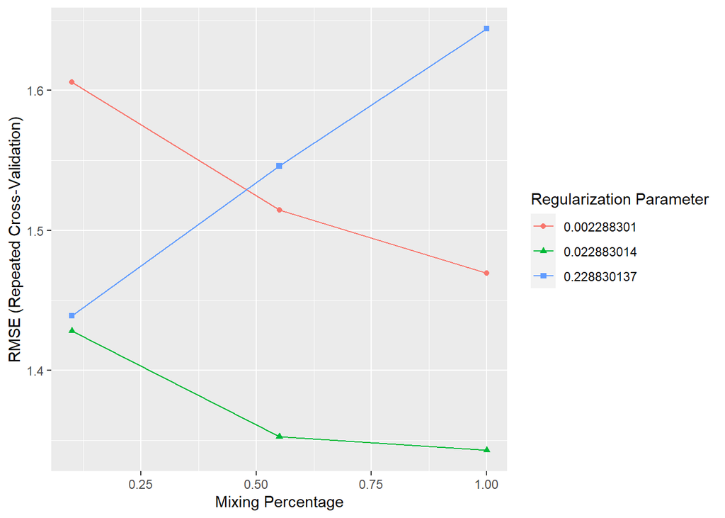

```r
ggplot(enet_full)
```

Alpha best at 1, so full Lasso.

Let’s tune it!

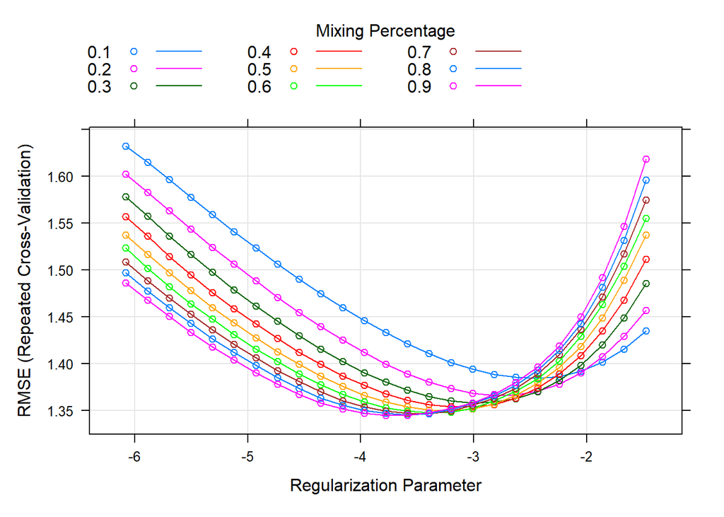

```r
my_lambda_grid <- exp(seq(log(min(enet_full$results$lambda)),
                          log(max(enet_full$results$lambda)),
                          length.out = 25))
enet_grid <- expand.grid(alpha = seq(0.1, 0.9, by = 0.1),
                         lambda = my_lambda_grid)
enet_full_tune <- train(y ~ m*((x1 + x2 + x3 + x4 + v1 + v2 + v3 + v4 + v5 + x5 + w + z +t)^2),
                        data = df,
                        method = "glmnet",
                        tuneGrid = enet_grid,
                        metric = my_metric,
                        preProcess = c("center", "scale"),
                        trControl = my_ctrl)

plot(enet_full_tune, xTrans=log)
```

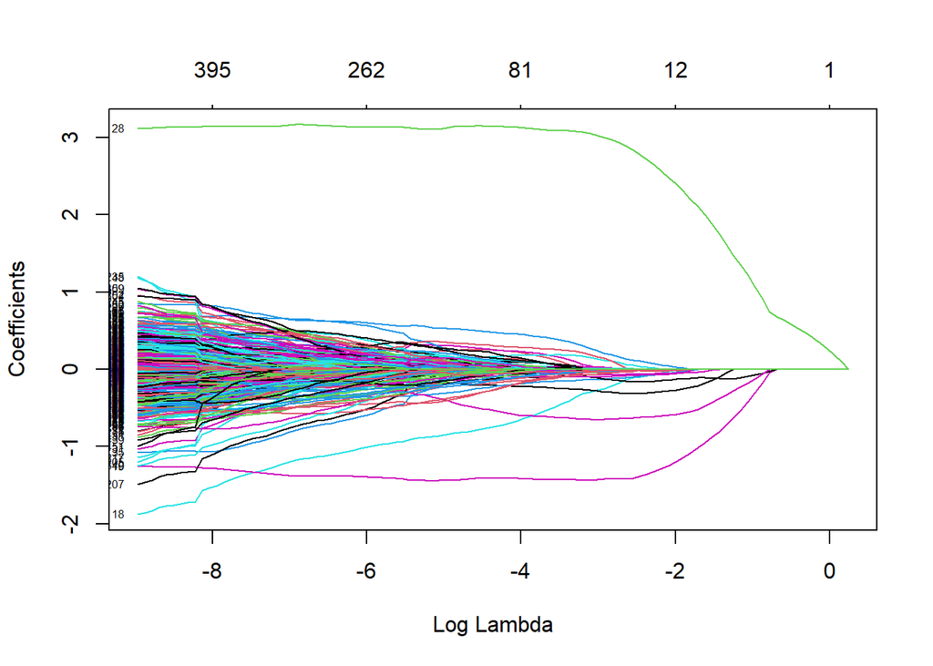

```r
plot(enet_full_tune$finalModel, xvar='lambda', label=TRUE)
```

```r
enet_full_tune$bestTune
```

```
##     alpha    lambda
## 214   0.9 0.0277234
```

Okay, again, high alpha is better.

**Polynomial from LMs**

```r
enet_poly <- train(y ~ x1 + x2 + x5 + z + v5 + I(x1^2) + I(x2^2) + I(x5^2) + I(z^2) + I(v5^2),
                   data = df,
                   method = "glmnet",
                   metric = my_metric,
                   preProcess = c("center", "scale"),
                   trControl = my_ctrl
)
enet_poly
```

```
## glmnet
##
## 1252 samples
##    5 predictor
##
## Pre-processing: centered (10), scaled (10)
## Resampling: Cross-Validated (5 fold, repeated 3 times)
## Summary of sample sizes: 1001, 1003, 1002, 1000, 1002, 1002, ...
## Resampling results across tuning parameters:
##
##   alpha  lambda       RMSE      Rsquared   MAE
##   0.10   0.002420184  1.397231  0.6362339  1.077685
##   0.10   0.024201839  1.429346  0.6227697  1.096234
##   0.10   0.242018387  1.661093  0.5101204  1.264023
##   0.55   0.002420184  1.396716  0.6364827  1.077185
##   0.55   0.024201839  1.436558  0.6187338  1.102766
##   0.55   0.242018387  1.784087  0.4303012  1.355602
##   1.00   0.002420184  1.396305  0.6366938  1.076683
##   1.00   0.024201839  1.454199  0.6086842  1.118719
##   1.00   0.242018387  1.848639  0.3931748  1.413365
##
## RMSE was used to select the optimal model using the smallest value.
## The final values used for the model were alpha = 1 and lambda = 0.002420184.
```

Similar to above, but smaller lambda..

###Neural Net

```r
neural_net_base <- train(y ~ x1 + x2 + x3 + x4 + v1 + v2 + v3 + v4 + v5 + m,
              data = df,
              method = "nnet",
              metric = my_metric,
              preProcess = c("center", "scale"),
              trControl = my_ctrl,
              trace = FALSE,
              linout = FALSE
              )
neural_net_base
```

```
## Neural Network
##
## 1252 samples
##   10 predictor
##
## Pre-processing: centered (13), scaled (13)
## Resampling: Cross-Validated (5 fold, repeated 3 times)
## Summary of sample sizes: 1002, 1002, 1001, 1002, 1001, 1001, ...
## Resampling results across tuning parameters:
##
##   size  decay  RMSE      Rsquared    MAE
##   1     0e+00  2.262496  0.05971582  1.757300
##   1     1e-04  2.209026  0.12022448  1.692383
##   1     1e-01  2.125921  0.34507572  1.594407
##   3     0e+00  2.216243  0.12626331  1.695142
##   3     1e-04  2.207957  0.12775636  1.687683
##   3     1e-01  2.079167  0.43895309  1.562998
##   5     0e+00  2.252538  0.07692225  1.744441
##   5     1e-04  2.212751  0.12365270  1.692193
##   5     1e-01  2.064601  0.46250806  1.557071
##
## RMSE was used to select the optimal model using the smallest value.
## The final values used for the model were size = 5 and decay = 0.1.
```

Interesting.. None of the results are great, but larger decay is better..

```r
neural_net_expanded <- train(y ~ x4 + x5 + v3 + v4 + v5 + w + z + t + m,
              data = df,
              method = "nnet",
              metric = my_metric,
              preProcess = c("center", "scale"),
              trControl = my_ctrl,
              trace = FALSE,
              linout = FALSE
              )
neural_net_expanded
```

```
## Neural Network
##
## 1252 samples
##    9 predictor
##
## Pre-processing: centered (12), scaled (12)
## Resampling: Cross-Validated (5 fold, repeated 3 times)
## Summary of sample sizes: 1000, 1003, 1002, 1002, 1001, 1001, ...
## Resampling results across tuning parameters:
##
##   size  decay  RMSE      Rsquared   MAE
##   1     0e+00  2.192758  0.1483614  1.677829
##   1     1e-04  2.140885  0.2572812  1.614311
##   1     1e-01  2.113500  0.3001409  1.603560
##   3     0e+00  2.183149  0.1580376  1.671702
##   3     1e-04  2.149960  0.2325029  1.629636
##   3     1e-01  2.116731  0.2949016  1.610847
##   5     0e+00  2.176977  0.1731111  1.656744
##   5     1e-04  2.146902  0.2421334  1.625574
##   5     1e-01  2.114011  0.2918813  1.611706
##
## RMSE was used to select the optimal model using the smallest value.
## The final values used for the model were size = 1 and decay = 0.1.
```

Let’s try a tune?

```r
nnet_grid <- expand.grid(size = c(2, 4, 6, 8, 10, 12),
                         decay = exp(seq(-6, 2, length.out = 13)))
neural_net_expanded_tune <- train(y ~ x4 + x5 + v3 + v4 + v5 + w + z + t + m,
              data = df,
              method = "nnet",
              metric = my_metric,
              tuneGrid = nnet_grid,
              preProcess = c("center", "scale"),
              trControl = my_ctrl,
              trace = FALSE,
              linout = FALSE
              )
```

Wow that took a long time..

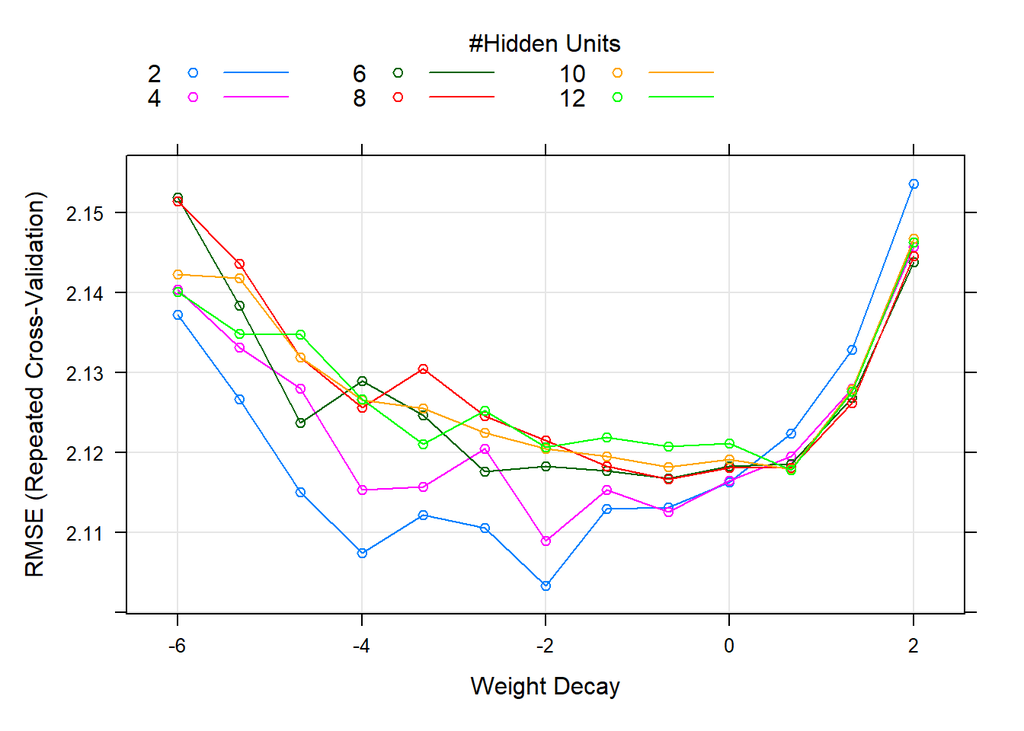

```r
plot(neural_net_expanded_tune, xTrans = log)
```

Interesting.. The neural net with 2 hidden units actually achieves the best performance around decay = exp(-2). Perhaps the more complex ones end up overfitting.

###Random Forest

```r
random_forest_base <- train(y ~ x1 + x2 + x3 + x4 + v1 + v2 + v3 + v4 + v5 + m,
                            data = df,
                            method = "rf",
                            metric = my_metric,
                            trControl = my_ctrl,
                            importance = TRUE
                            )
random_forest_base
```

```
## Random Forest
##
## 1252 samples
##   10 predictor
##
## No pre-processing
## Resampling: Cross-Validated (5 fold, repeated 3 times)
## Summary of sample sizes: 1002, 1002, 1002, 1001, 1001, 1003, ...
## Resampling results across tuning parameters:
##
##   mtry  RMSE      Rsquared   MAE
##    2    1.753253  0.5359669  1.3311520
##    7    1.299520  0.7072598  0.9554591
##   13    1.171750  0.7511733  0.8582508
##
## RMSE was used to select the optimal model using the smallest value.
## The final value used for the model was mtry = 13.
```

```r
random_forest_expanded <- train(y ~ x4 + x5 + v3 + v4 + v5 + w + z + t + m,
                                data = df,
                                method = "rf",
                                metric = my_metric,
                                trControl = my_ctrl,
                                importance = TRUE)
random_forest_expanded
```

```
## Random Forest
##
## 1252 samples
##    9 predictor
##
## No pre-processing
## Resampling: Cross-Validated (5 fold, repeated 3 times)
## Summary of sample sizes: 1001, 1003, 1000, 1002, 1002, 1002, ...
## Resampling results across tuning parameters:
##
##   mtry  RMSE      Rsquared   MAE
##    2    1.585387  0.5601803  1.216019
##    7    1.384529  0.6437923  1.029505
##   12    1.371875  0.6484509  1.014165
##
## RMSE was used to select the optimal model using the smallest value.
## The final value used for the model was mtry = 12.
```

Base features random forest achieves pretty good performance..

###GB Tree

```r
xgb_base <- train(y ~ x1 + x2 + x3 + x4 + v1 + v2 + v3 + v4 + v5 + m,
                 data = df,
                 method = "xgbTree",
                 metric = my_metric,
                 trControl = my_ctrl,
                 objective = 'reg:squarederror')
```

[output not shown]

[output not shown]

[output not shown]

[output not shown]

[output not shown]

[output not shown]

[output not shown]

[output not shown]

[output not shown]

[output not shown]

[output not shown]

[output not shown]

[output not shown]

[output not shown]

[output not shown]

[output not shown]

[output not shown]

[output not shown]

[output not shown]

[output not shown]

[output not shown]

[output not shown]

[output not shown]

[output not shown]

[output not shown]

[output not shown]

[output not shown]

[output not shown]

[output not shown]

[output not shown]

[output not shown]

[output not shown]

[output not shown]

[output not shown]

[output not shown]

[output not shown]

[output not shown]

[output not shown]

[output not shown]

[output not shown]

[output not shown]

[output not shown]

[output not shown]

[output not shown]

[output not shown]

[output not shown]

[output not shown]

[output not shown]

[output not shown]

[output not shown]

[output not shown]

[output not shown]

[output not shown]

[output not shown]

[output not shown]

[output not shown]

[output not shown]

[output not shown]

[output not shown]

[output not shown]

[output not shown]

[output not shown]

[output not shown]

[output not shown]

[output not shown]

[output not shown]

[output not shown]

[output not shown]

[output not shown]

[output not shown]

[output not shown]

[output not shown]

[output not shown]

[output not shown]

[output not shown]

[output not shown]

[output not shown]

[output not shown]

[output not shown]

[output not shown]

[output not shown]

[output not shown]

[output not shown]

[output not shown]

[output not shown]

[output not shown]

[output not shown]

[output not shown]

[output not shown]

[output not shown]

[output not shown]

[output not shown]

[output not shown]

[output not shown]

[output not shown]

[output not shown]

[output not shown]

[output not shown]

[output not shown]

[output not shown]

[output not shown]

[output not shown]

[output not shown]

[output not shown]

[output not shown]

[output not shown]

[output not shown]

[output not shown]

[output not shown]

[output not shown]

[output not shown]

[output not shown]

[output not shown]

[output not shown]

[output not shown]

[output not shown]

[output not shown]

[output not shown]

[output not shown]

[output not shown]

[output not shown]

[output not shown]

[output not shown]

[output not shown]

[output not shown]

[output not shown]

[output not shown]

[output not shown]

[output not shown]

[output not shown]

[output not shown]

[output not shown]

[output not shown]

[output not shown]

[output not shown]

[output not shown]

[output not shown]

[output not shown]

[output not shown]

[output not shown]

[output not shown]

[output not shown]

[output not shown]

[output not shown]

[output not shown]

[output not shown]

[output not shown]

[output not shown]

[output not shown]

[output not shown]

[output not shown]

[output not shown]

[output not shown]

[output not shown]

[output not shown]

[output not shown]

[output not shown]

[output not shown]

[output not shown]

[output not shown]

[output not shown]

[output not shown]

[output not shown]

[output not shown]

[output not shown]

[output not shown]

[output not shown]

[output not shown]

[output not shown]

[output not shown]

[output not shown]

[output not shown]

[output not shown]

[output not shown]

[output not shown]

[output not shown]

[output not shown]

[output not shown]

[output not shown]

[output not shown]

[output not shown]

[output not shown]

[output not shown]

[output not shown]

[output not shown]

[output not shown]

[output not shown]

[output not shown]

[output not shown]

[output not shown]

[output not shown]

[output not shown]

[output not shown]

[output not shown]

[output not shown]

[output not shown]

[output not shown]

[output not shown]

[output not shown]

[output not shown]

[output not shown]

[output not shown]

[output not shown]

[output not shown]

[output not shown]

[output not shown]

[output not shown]

[output not shown]

[output not shown]

[output not shown]

[output not shown]

[output not shown]

[output not shown]

[output not shown]

[output not shown]

[output not shown]

[output not shown]

[output not shown]

[output not shown]

[output not shown]

[output not shown]

[output not shown]

[output not shown]

[output not shown]

[output not shown]

[output not shown]

[output not shown]

[output not shown]

[output not shown]

[output not shown]

[output not shown]

[output not shown]

[output not shown]

[output not shown]

[output not shown]

[output not shown]

[output not shown]

[output not shown]

[output not shown]

[output not shown]

[output not shown]

[output not shown]

[output not shown]

[output not shown]

[output not shown]

[output not shown]

[output not shown]

[output not shown]

[output not shown]

[output not shown]

[output not shown]

[output not shown]

[output not shown]

[output not shown]

[output not shown]

[output not shown]

[output not shown]

[output not shown]

[output not shown]

[output not shown]

[output not shown]

[output not shown]

[output not shown]

[output not shown]

[output not shown]

[output not shown]

[output not shown]

[output not shown]

[output not shown]

[output not shown]

[output not shown]

[output not shown]

[output not shown]

[output not shown]

[output not shown]

[output not shown]

[output not shown]

[output not shown]

[output not shown]

[output not shown]

[output not shown]

[output not shown]

[output not shown]

[output not shown]

[output not shown]

[output not shown]

[output not shown]

[output not shown]

[output not shown]

[output not shown]

[output not shown]

[output not shown]

[output not shown]

[output not shown]

[output not shown]

[output not shown]

[output not shown]

[output not shown]

[output not shown]

[output not shown]

[output not shown]

[output not shown]

[output not shown]

[output not shown]

[output not shown]

[output not shown]

[output not shown]

[output not shown]

[output not shown]

[output not shown]

[output not shown]

[output not shown]

[output not shown]

[output not shown]

[output not shown]

[output not shown]

[output not shown]

[output not shown]

[output not shown]

[output not shown]

[output not shown]

[output not shown]

[output not shown]

[output not shown]

[output not shown]

[output not shown]

[output not shown]

[output not shown]

[output not shown]

[output not shown]

[output not shown]

[output not shown]

[output not shown]

[output not shown]

[output not shown]

[output not shown]

[output not shown]

[output not shown]

[output not shown]

[output not shown]

[output not shown]

[output not shown]

[output not shown]

[output not shown]

[output not shown]

[output not shown]

[output not shown]

[output not shown]

[output not shown]

[output not shown]

[output not shown]

[output not shown]

[output not shown]

[output not shown]

[output not shown]

[output not shown]

[output not shown]

[output not shown]

[output not shown]

[output not shown]

[output not shown]

[output not shown]

[output not shown]

[output not shown]

[output not shown]

[output not shown]

[output not shown]

[output not shown]

[output not shown]

[output not shown]

[output not shown]

[output not shown]

[output not shown]

[output not shown]

[output not shown]

[output not shown]

[output not shown]

[output not shown]

[output not shown]

[output not shown]

[output not shown]

[output not shown]

[output not shown]

[output not shown]

[output not shown]

[output not shown]

[output not shown]

[output not shown]

[output not shown]

[output not shown]

[output not shown]

[output not shown]

[output not shown]

[output not shown]

[output not shown]

[output not shown]

[output not shown]

[output not shown]

[output not shown]

[output not shown]

[output not shown]

[output not shown]

[output not shown]

[output not shown]

[output not shown]

[output not shown]

[output not shown]

[output not shown]

[output not shown]

[output not shown]

[output not shown]

[output not shown]

[output not shown]

[output not shown]

[output not shown]

[output not shown]

[output not shown]

[output not shown]

[output not shown]

[output not shown]

[output not shown]

[output not shown]

[output not shown]

[output not shown]

[output not shown]

[output not shown]

[output not shown]

[output not shown]

[output not shown]

[output not shown]

[output not shown]

[output not shown]

[output not shown]

[output not shown]

[output not shown]

[output not shown]

[output not shown]

[output not shown]

[output not shown]

[output not shown]

[output not shown]

[output not shown]

[output not shown]

[output not shown]

[output not shown]

[output not shown]

[output not shown]

[output not shown]

[output not shown]

[output not shown]

[output not shown]

[output not shown]

[output not shown]

[output not shown]

[output not shown]

[output not shown]

[output not shown]

[output not shown]

[output not shown]

[output not shown]

[output not shown]

[output not shown]

[output not shown]

[output not shown]

[output not shown]

[output not shown]

[output not shown]

[output not shown]

[output not shown]

[output not shown]

[output not shown]

[output not shown]

[output not shown]

[output not shown]

[output not shown]

[output not shown]

[output not shown]

[output not shown]

[output not shown]

[output not shown]

[output not shown]

[output not shown]

[output not shown]

[output not shown]

[output not shown]

[output not shown]

[output not shown]

[output not shown]

[output not shown]

[output not shown]

[output not shown]

[output not shown]

[output not shown]

[output not shown]

[output not shown]

[output not shown]

[output not shown]

[output not shown]

[output not shown]

[output not shown]

[output not shown]

[output not shown]

[output not shown]

[output not shown]

[output not shown]

[output not shown]

[output not shown]

[output not shown]

[output not shown]

[output not shown]

[output not shown]

[output not shown]

[output not shown]

[output not shown]

[output not shown]

[output not shown]

[output not shown]

[output not shown]

[output not shown]

[output not shown]

[output not shown]

[output not shown]

[output not shown]

[output not shown]

[output not shown]

[output not shown]

[output not shown]

[output not shown]

[output not shown]

[output not shown]

[output not shown]

[output not shown]

[output not shown]

[output not shown]

[output not shown]

[output not shown]

[output not shown]

[output not shown]

[output not shown]

[output not shown]

```r
xgb_base
```

```
## eXtreme Gradient Boosting
##
## 1252 samples
##   10 predictor
##
## No pre-processing
## Resampling: Cross-Validated (5 fold, repeated 3 times)
## Summary of sample sizes: 1002, 1003, 1002, 1000, 1001, 1002, ...
## Resampling results across tuning parameters:
##
##   eta  max_depth  colsample_bytree  subsample  nrounds  RMSE      Rsquared
##   0.3  1          0.6               0.50        50      1.782575  0.4074705
##   0.3  1          0.6               0.50       100      1.773036  0.4133222
##   0.3  1          0.6               0.50       150      1.765587  0.4192689
##   0.3  1          0.6               0.75        50      1.757341  0.4259524
##   0.3  1          0.6               0.75       100      1.736392  0.4368933
##   0.3  1          0.6               0.75       150      1.735633  0.4371674
##   0.3  1          0.6               1.00        50      1.764938  0.4235145
##   0.3  1          0.6               1.00       100      1.728361  0.4430950
##   0.3  1          0.6               1.00       150      1.723984  0.4450280
##   0.3  1          0.8               0.50        50      1.767136  0.4168612
##   0.3  1          0.8               0.50       100      1.755890  0.4235130
##   0.3  1          0.8               0.50       150      1.758884  0.4231815
##   0.3  1          0.8               0.75        50      1.749864  0.4298519
##   0.3  1          0.8               0.75       100      1.743115  0.4328343
##   0.3  1          0.8               0.75       150      1.745620  0.4316082
##   0.3  1          0.8               1.00        50      1.751714  0.4316533
##   0.3  1          0.8               1.00       100      1.726228  0.4445434
##   0.3  1          0.8               1.00       150      1.722643  0.4459294
##   0.3  2          0.6               0.50        50      1.569927  0.5391402
##   0.3  2          0.6               0.50       100      1.530930  0.5599555
##   0.3  2          0.6               0.50       150      1.498413  0.5794119
##   0.3  2          0.6               0.75        50      1.515369  0.5722083
##   0.3  2          0.6               0.75       100      1.471054  0.5943144
##   0.3  2          0.6               0.75       150      1.453315  0.6037846
##   0.3  2          0.6               1.00        50      1.470416  0.5998709
##   0.3  2          0.6               1.00       100      1.411057  0.6275841
##   0.3  2          0.6               1.00       150      1.398378  0.6335451
##   0.3  2          0.8               0.50        50      1.474396  0.5939700
##   0.3  2          0.8               0.50       100      1.429142  0.6171170
```

[output cut: 181 more lines]

```
##   1.1144431
##   1.0181725
##   1.0167104
##   1.0229609
##   1.0147107
##   0.9877826
##   0.9845029
##
## Tuning parameter 'gamma' was held constant at a value of 0
## Tuning
##  parameter 'min_child_weight' was held constant at a value of 1
## RMSE was used to select the optimal model using the smallest value.
## The final values used for the model were nrounds = 150, max_depth = 3, eta
##  = 0.3, gamma = 0, colsample_bytree = 0.8, min_child_weight = 1 and subsample
##  = 1.
```

```r
xgb_base$bestTune
```

```
##    nrounds max_depth eta gamma colsample_bytree min_child_weight subsample
## 54     150         3 0.3     0              0.8                1         1
```

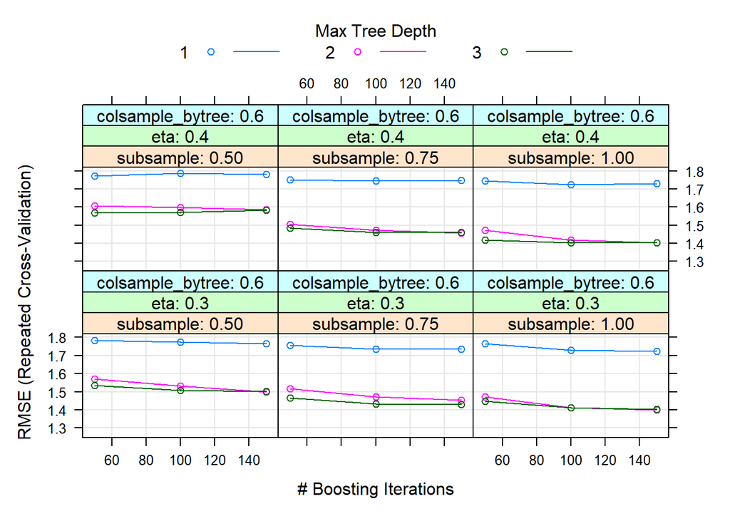

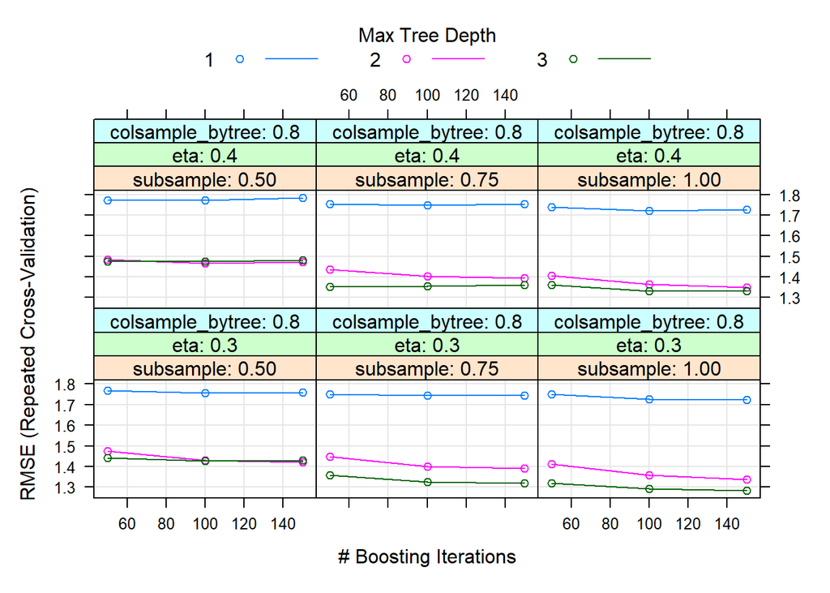

```r
plot(xgb_base)
```

Deeper trees perform better across the board. More iterations are ususally better. The best tune has depth of 3, eta of .3, and subsample of 1.

```r
xgb_exp <- train(y ~ x4 + x5 + v3 + v4 + v5 + w + z + t + m,
                 data = df,
                 method = "xgbTree",
                 metric = my_metric,
                 trControl = my_ctrl,
                 objective = 'reg:squarederror')
```

[output not shown]

[output not shown]

[output not shown]

[output not shown]

[output not shown]

[output not shown]

[output not shown]

[output not shown]

[output not shown]

[output not shown]

[output not shown]

[output not shown]

[output not shown]

[output not shown]

[output not shown]

[output not shown]

[output not shown]

[output not shown]

[output not shown]

[output not shown]

[output not shown]

[output not shown]

[output not shown]

[output not shown]

[output not shown]

[output not shown]

[output not shown]

[output not shown]

[output not shown]

[output not shown]

[output not shown]

[output not shown]

[output not shown]

[output not shown]

[output not shown]

[output not shown]

[output not shown]

[output not shown]

[output not shown]

[output not shown]

[output not shown]

[output not shown]

[output not shown]

[output not shown]

[output not shown]

[output not shown]

[output not shown]

[output not shown]

[output not shown]

[output not shown]

[output not shown]

[output not shown]

[output not shown]

[output not shown]

[output not shown]

[output not shown]

[output not shown]

[output not shown]

[output not shown]

[output not shown]

[output not shown]

[output not shown]

[output not shown]

[output not shown]

[output not shown]

[output not shown]

[output not shown]

[output not shown]

[output not shown]

[output not shown]

[output not shown]

[output not shown]

[output not shown]

[output not shown]

[output not shown]

[output not shown]

[output not shown]

[output not shown]

[output not shown]

[output not shown]

[output not shown]

[output not shown]

[output not shown]

[output not shown]

[output not shown]

[output not shown]

[output not shown]

[output not shown]

[output not shown]

[output not shown]

[output not shown]

[output not shown]

[output not shown]

[output not shown]

[output not shown]

[output not shown]

[output not shown]

[output not shown]

[output not shown]

[output not shown]

[output not shown]

[output not shown]

[output not shown]

[output not shown]

[output not shown]

[output not shown]

[output not shown]

[output not shown]

[output not shown]

[output not shown]

[output not shown]

[output not shown]

[output not shown]

[output not shown]

[output not shown]

[output not shown]

[output not shown]

[output not shown]

[output not shown]

[output not shown]

[output not shown]

[output not shown]

[output not shown]

[output not shown]

[output not shown]

[output not shown]

[output not shown]

[output not shown]

[output not shown]

[output not shown]

[output not shown]

[output not shown]

[output not shown]

[output not shown]

[output not shown]

[output not shown]

[output not shown]

[output not shown]

[output not shown]

[output not shown]

[output not shown]

[output not shown]

[output not shown]

[output not shown]

[output not shown]

[output not shown]

[output not shown]

[output not shown]

[output not shown]

[output not shown]

[output not shown]

[output not shown]

[output not shown]

[output not shown]

[output not shown]

[output not shown]

[output not shown]

[output not shown]

[output not shown]

[output not shown]

[output not shown]

[output not shown]

[output not shown]

[output not shown]

[output not shown]

[output not shown]

[output not shown]

[output not shown]

[output not shown]

[output not shown]

[output not shown]

[output not shown]

[output not shown]

[output not shown]

[output not shown]

[output not shown]

[output not shown]

[output not shown]

[output not shown]

[output not shown]

[output not shown]

[output not shown]

[output not shown]

[output not shown]

[output not shown]

[output not shown]

[output not shown]

[output not shown]

[output not shown]

[output not shown]

[output not shown]

[output not shown]

[output not shown]

[output not shown]

[output not shown]

[output not shown]

[output not shown]

[output not shown]

[output not shown]

[output not shown]

[output not shown]

[output not shown]

[output not shown]

[output not shown]

[output not shown]

[output not shown]

[output not shown]

[output not shown]

[output not shown]

[output not shown]

[output not shown]

[output not shown]

[output not shown]

[output not shown]

[output not shown]

[output not shown]

[output not shown]

[output not shown]

[output not shown]

[output not shown]

[output not shown]

[output not shown]

[output not shown]

[output not shown]

[output not shown]

[output not shown]

[output not shown]

[output not shown]

[output not shown]

[output not shown]

[output not shown]

[output not shown]

[output not shown]

[output not shown]

[output not shown]

[output not shown]

[output not shown]

[output not shown]

[output not shown]

[output not shown]

[output not shown]

[output not shown]

[output not shown]

[output not shown]

[output not shown]

[output not shown]

[output not shown]

[output not shown]

[output not shown]

[output not shown]

[output not shown]

[output not shown]

[output not shown]

[output not shown]

[output not shown]

[output not shown]

[output not shown]

[output not shown]

[output not shown]

[output not shown]

[output not shown]

[output not shown]

[output not shown]

[output not shown]

[output not shown]

[output not shown]

[output not shown]

[output not shown]

[output not shown]

[output not shown]

[output not shown]

[output not shown]

[output not shown]

[output not shown]

[output not shown]

[output not shown]

[output not shown]

[output not shown]

[output not shown]

[output not shown]

[output not shown]

[output not shown]

[output not shown]

[output not shown]

[output not shown]

[output not shown]

[output not shown]

[output not shown]

[output not shown]

[output not shown]

[output not shown]

[output not shown]

[output not shown]

[output not shown]

[output not shown]

[output not shown]

[output not shown]

[output not shown]

[output not shown]

[output not shown]

[output not shown]

[output not shown]

[output not shown]

[output not shown]

[output not shown]

[output not shown]

[output not shown]

[output not shown]

[output not shown]

[output not shown]

[output not shown]

[output not shown]

[output not shown]

[output not shown]

[output not shown]

[output not shown]

[output not shown]

[output not shown]

[output not shown]

[output not shown]

[output not shown]

[output not shown]

[output not shown]

[output not shown]

[output not shown]

[output not shown]

[output not shown]

[output not shown]

[output not shown]

[output not shown]

[output not shown]

[output not shown]

[output not shown]

[output not shown]

[output not shown]

[output not shown]

[output not shown]

[output not shown]

[output not shown]

[output not shown]

[output not shown]

[output not shown]

[output not shown]

[output not shown]

[output not shown]

[output not shown]

[output not shown]

[output not shown]

[output not shown]

[output not shown]

[output not shown]

[output not shown]

[output not shown]

[output not shown]

[output not shown]

[output not shown]

[output not shown]

[output not shown]

[output not shown]

[output not shown]

[output not shown]

[output not shown]

[output not shown]

[output not shown]

[output not shown]

[output not shown]

[output not shown]

[output not shown]

[output not shown]

[output not shown]

[output not shown]

[output not shown]

[output not shown]

[output not shown]

[output not shown]

[output not shown]

[output not shown]

[output not shown]

[output not shown]

[output not shown]

[output not shown]

[output not shown]

[output not shown]

[output not shown]

[output not shown]

[output not shown]

[output not shown]

[output not shown]

[output not shown]

[output not shown]

[output not shown]

[output not shown]

[output not shown]

[output not shown]

[output not shown]

[output not shown]

[output not shown]

[output not shown]

[output not shown]

[output not shown]

[output not shown]

[output not shown]

[output not shown]

[output not shown]

[output not shown]

[output not shown]

[output not shown]

[output not shown]

[output not shown]

[output not shown]

[output not shown]

[output not shown]

[output not shown]

[output not shown]

[output not shown]

[output not shown]

[output not shown]